# Medidas de centralidad y sesgo.

Yubar Daniel Marín Benjumea

https://unalyticsteam.github.io/unalytics.github.io/

```r
base <- read.csv("../Bases de datos/auto-mpg.csv")
library(modeest) # Moda
library(raster) #quantiles, coeficiente de variación
library(moments)# asimetría, curtosis
```

```r
library(ggplot2)
```

# Medidas de tendencia central

Estas medidas me permiten tener un idea sobre que tan centrados se encuentran los datos.

## Media aritmética

$$\bar{x}=\frac{\sum_{i=1} ^n x_i}{n}$$

```r
mean(base$weight)
```

```
## [1] 2970.425
```

## Mediana

Es el valor bajo el cual se encuentra el 50% de los datos.

$$P(X\leq m)=0.5$$

```r
median(base$weight)
```

```
## [1] 2803.5
```

## Moda

Es el valor más frecuente en el conjunto de datos.

$$p(X = M) \ \geq p(x = x_i) , \ \forall _i = 1,2,...,n$$

```r
mfv(base$mpg)
```

```
## [1] 13
```

## Percentil

Funciona similar a la media solo que con este valor se busca que la probabilidad o el corte pueda quedar en cualquier valor entre 0 y 1.

$$P(X \leq x_p) = p, \ p \in[0,1]$$

```r
quantile(base$mpg)
```

```
##   0%  25%  50%  75% 100%
##  9.0 17.5 23.0 29.0 46.6
```

```r
quantile(base$mpg, c(0.2,0.6))
```

```
## 20% 60%
##  16  25
```

# Medidas de dispesión

Permiten evaluar cuánto queremos saber que tan desplazados están los valores con respecto a la media.

## Varianza y desviación estandar

$$s^2=\frac{\sum_{i=1}^n (x_i-\bar{x})^2}{n-1}$$
La desviación estándar es usada con el propósito de llevar los resultados de la varianza a la escala original de los datos.

$$s = \sqrt s^2$$

```r
var(base$displacement)
```

```
## [1] 10872.2
```

```r
sd(base$displacement)
```

```
## [1] 104.2698
```

## Coeficiente de variación

$$CV = \frac{s}{\bar{x}}*100$$

```r
cv(base$displacement)
```

```
## [1] 53.90687
```

# Medidas de simetría y sesgo

## Asimetría de Fisher

Me da una idea hacia donde están concentrados la mayoría de los datos.

$$CA = \frac{\sum_{i=1}^n (x_i-\bar{x})^3}{n\ s^3}$$
* Si la asimetría es **negativa** se tiene una distribución con una gran concentración de datos a la derecha de la media.

- Si la asimetría es **cero** se tiene una distribución con una gra concentración de datos en la media.
- Si la asimetría es **positiva** se tiene una distribución con una gran concentración de datos a la izquierda de la media.

```r
skewness(base$mpg)
```

```
## [1] 0.4553419
```

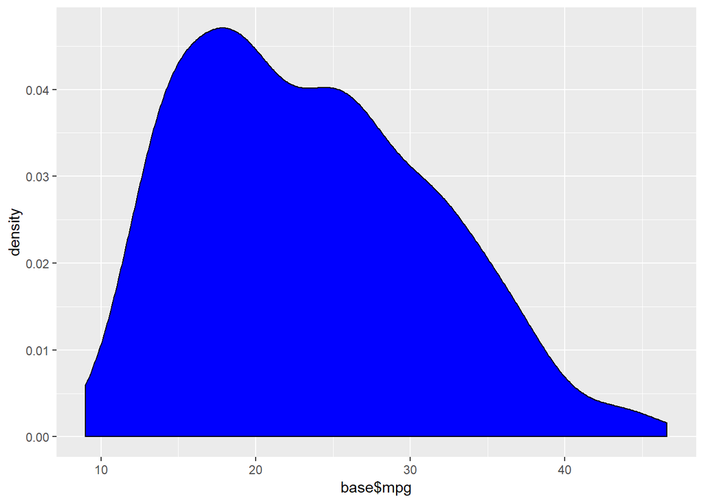

```r
ggplot(base, aes(base$mpg)) + geom_density(fill = "blue")
```

## Curtosis

$$C = \frac{\sum_{i=1}^n (x_i-\bar{x})^4}{n\ s^4}-3$$
* Si la curtosis es **negativa** se tiene una distribución con una gran dispersión de los datos , con grandes colas y algo aplastada.

- Si la curtosis es **positiva** se tiene una distribución con una baja dispersión de los datos , con colas pequeñas alrededor de la media.
- Si la curtosis es **cero** se tiene una distribución con una estructura similar a una normal.

```r
kurtosis(base$acceleration)
```

```
## [1] 3.399208
```

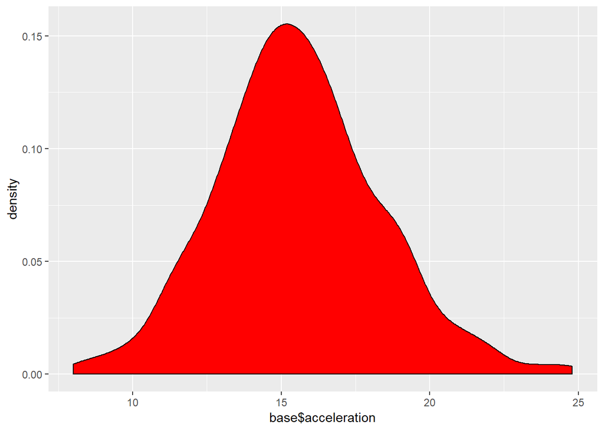

```r
ggplot(base, aes(base$acceleration)) + geom_density(fill = "red")
```